# RBIF112 - Assignment 2

Author: Neshita Kipuw

Last update: 09 September, 2025

```r
knitr::opts_chunk$set(echo = TRUE)
homedir <- "H:/My Drive/RBIF112/wk2/HW-files" # object containing a home directory path in R ( in this code chunk), and in python (The next code chunk).
setwd(homedir)
#library(reticulate) # required package for the execution of python code from R.
## check the path of python
## here for example: if you have a conda env where python is installed, you can activate the conda env and find the path to the python: `which python`
#use_python("C:/Users/nessi/miniconda3/envs/hw1/python.exe") # Path to the directory where python is stored on your computer.
```

```python
#import os
#homedir = "H:/My Drive/RBIF112/wk2/HW-files"
#os.chdir(homedir)
```

# 1 DEseq Analysis of Data set Classes

## 1.1 Download dataset from GEO

The code below will download the data set from GEO.

```r
#library(GEOquery)
#library(org.Hs.eg.db)   # Human-specific annotation
#library(AnnotationDbi)


GEODataDownload <- function(DS, gpl, gsm, PlateAnnotInfo, GenerateMetaData, Technology){
  library(DESeq2); library(limma); library(data.table)
  if(Technology == "Array"){
    gset <- getGEO(DS)
    if(length(gset) > 1) idx <- grep(gpl, attr(gset, "names")) else idx <- 1
    gset <- gset[[idx]]
    fvarLabels(gset) <- make.names(fvarLabels(gset))
    comp <- gsub(" ", "", gsm)
    comp <- gsub(",", "", comp)
    gsms <- paste0(comp)
    #### Set up raw names ####
    sml <- c()
    for(i in 1:nchar(gsms)){ sml[i] <- substr(gsms,i,i)}
    ex <- exprs(gset)
    qx <- as.numeric(quantile(ex, c(0., 0.25, 0.5, 0.75, 0.99, 1.0), na.rm=T))
    LogC <- (qx[5] > 100) ||
      (qx[6]-qx[1] > 50 && qx[2] > 0) ||
      (qx[2] > 0 && qx[2] < 1 && qx[4] < 2)
    if(LogC){ ex[which(ex <= 0)] <- NaN
    exprs(gset) <- log2(ex) }
    sml <- paste("G", sml, sep="")
    f1 <- as.factor(sml)
    gset$description2 <- f1
    design <- model.matrix(~description2 + 0, gset)
    colnames(design) <- levels(f1)
    fit <- lmFit(gset, design)
    cont.matrix <- makeContrasts(G1-G0, levels = design)
    fit2 <- contrasts.fit(fit, cont.matrix)
    fit2 <- eBayes(fit2, 0.01)
    tT <- topTable(fit2, adjust="fdr", sort.by = "B", number = 25000000000)
    #### subset ####
    ex2 <- data.table(subset(tT, select=c("ID", "logFC", "P.Value", "adj.P.Val")))
    ex2$ID <- as.character(ex2$ID)
    #### annotate with gene names ####
    plat <- PlateAnnotInfo[GPLID == gpl,][,!"GPLID", with = FALSE]
    if(nrow(plat) == 0){ print(paste("There is no annotation information available for", gpl)) }
    plat$ID <- as.character(plat$ID)
    plat <- plat[!duplicated(plat$ID),]
    ex2 <- merge(plat, ex2, by = "ID")
    ex2$ID <- as.character(ex2$ID)
    exraw <- data.table(ex)
    exraw$ID <- as.character(rownames(ex))
    #### annotate raw data with gene names ####
    ex2 <- merge(ex2, exraw, by = "ID")
    #### Generate Meta Data ####
    Pdat <- pData(gset)
    #### Add Meta data ####
    Pdat <- as.data.table(Pdat)
    return(list(Data = ex2, MetaData = Pdat))
  }

  if(Technology == "RNAseq"){
    ACC <- paste("acc=", DS, sep = "")
    file <- paste("file=", DS, "_raw_counts_GRCh38.p13_NCBI.tsv.gz", sep = "")
    comp <- gsub(" ", "", gsm)
    comp <- gsub(",", "", comp)
    gsms <- paste0(comp)
    #### Set up DEG names ####
    urld <- "https://www.ncbi.nlm.nih.gov/geo/download/?format=file&type=rnaseq_counts"
    path <- paste(urld, ACC, file, sep="&");
    tbl <- as.matrix(data.table::fread(path, header=T, colClasses="integer"), rownames="GeneID")
    exraw <- tbl
    apath <- paste(urld, "type=rnaseq_counts", "file=Human.GRCh38.p13.annot.tsv.gz", sep="&")
    annot <- data.table::fread(apath, header=T, quote="", stringsAsFactors=F, data.table=F)
    rownames(annot) <- annot$GeneID
    sml <- strsplit(gsms, split="")[[1]]
    sel <- which(sml != "X")
    sml <- sml[sel]
    tbl <- tbl[ ,sel]
    gs <- factor(sml)
    groups <- make.names(c("Ctrl", "Tx"))
    levels(gs) <- groups
    sample_info <- data.frame(Group = gs, row.names = colnames(tbl))
    keep <- rowSums( tbl >= 10 ) >= min(table(gs))
    tbl <- tbl[keep, ]
    ds <- DESeqDataSetFromMatrix(countData=tbl, colData=sample_info, design= ~Group)
    ds <- DESeq(ds, test="Wald", sfType="poscount")
    r <- results(ds, contrast=c("Group", groups[2], groups[1]), alpha=0.05, pAdjustMethod ="fdr")
    tT <- r[order(r$padj)[1:length(r$padj)],]
    tT <- merge(as.data.frame(tT), annot, by=0, sort=F)
    tT <- subset(tT, select=c("GeneID","padj","pvalue","lfcSE","stat","log2FoldChange","baseMean","Symbol","Description"))
    #### subset ####
    ex2 <- data.table(subset(tT, select=c("GeneID", "Symbol", "Description", "log2FoldChange", "pvalue", "padj")))
    #### Adjust column names ####
    setnames(ex2, c("GeneID", "Symbol", "Description"), c("ENTREZID", "SYMBOL", "GENENAME"))
    #### Get Raw data ####
    GeneID <- as.integer(rownames(exraw))
    exraw <- as.data.table(exraw)
    #### Update column names ####
    exraw$ENTREZID <- GeneID
    #### merge FC and raw data together ####
    mer <- merge(ex2, exraw, by = "ENTREZID")
    return(mer)
  }
}


# Execute the GEODataDownload function and obtain the RNAseq data set
RNAseqData <- GEODataDownload(DS = "GSE247146",
                              gpl = "GPL30173",
                              gsm = "11010101001111111000000",
                              PlateAnnotInfo = "Only needed if the data was generated using MicroArrays",
                              GenerateMetaData = "Only needed if the data was generated using MicroArrays",
                              Technology = "RNAseq")
data.table(head(as.data.frame(RNAseqData),10), filter = 'top', options = list(pageLength = 10, scrollX = TRUE, scrollY = "400px", autoWidth = TRUE))
```

```
##     ENTREZID SYMBOL                                  GENENAME log2FoldChange
##        <int> <char>                                    <char>          <num>
##  1:        1   A1BG                    alpha-1-B glycoprotein    -0.18164865
##  2:        2    A2M                     alpha-2-macroglobulin     0.11838314
##  3:        9   NAT1                     N-acetyltransferase 1    -0.03941396
##  4:       14   AAMP   angio associated migratory cell protein    -0.09627424
##  5:       15  AANAT          aralkylamine N-acetyltransferase    -0.46815862
##  6:       16  AARS1                  alanyl-tRNA synthetase 1     0.15563929
##  7:       18   ABAT          4-aminobutyrate aminotransferase    -0.02584189
##  8:       19  ABCA1 ATP binding cassette subfamily A member 1    -0.14815718
##  9:       20  ABCA2 ATP binding cassette subfamily A member 2     0.12532644
## 10:       21  ABCA3 ATP binding cassette subfamily A member 3     0.11732299
##        pvalue      padj GSM7884318 GSM7884320 GSM7884321 GSM7884322 GSM7884323
##         <num>     <num>      <int>      <int>      <int>      <int>      <int>
##  1: 0.3265879 0.9997078         52         55         76         29         78
```

[output cut: 57 more lines]

```r
# Save the RNAseq data set to the working directory
saveRDS(RNAseqData, file = "~/RNAseq_GSE247146.rds")

# Reload the file into R environment
GSE247146 <- readRDS("~/RNAseq_GSE247146.rds")
dim(GSE247146)
```

```
## [1] 15201    29
```

## 1.2 Summarized Experiment object

```r
library(SummarizedExperiment)

# get column names of GSE261186 data set
print(colnames(GSE247146))
```

```
##  [1] "ENTREZID"       "SYMBOL"         "GENENAME"       "log2FoldChange"
##  [5] "pvalue"         "padj"           "GSM7884318"     "GSM7884320"
##  [9] "GSM7884321"     "GSM7884322"     "GSM7884323"     "GSM7884324"
## [13] "GSM7884325"     "GSM7884326"     "GSM7884327"     "GSM7884328"
## [17] "GSM7884329"     "GSM7884330"     "GSM7884331"     "GSM7884332"
## [21] "GSM7884333"     "GSM7884334"     "GSM7884335"     "GSM7884336"
## [25] "GSM7884337"     "GSM7884338"     "GSM7884339"     "GSM7884340"
## [29] "GSM7884341"
```

```r
# specify which columns are count data (numeric columns that are not annotation)
numeric_cols <- sapply(GSE247146, is.numeric)
annotation_cols <- c("ENTREZID", "SYMBOL", "GENENAME", "log2FoldChange", "pvalue", "padj")
count_cols <- names(GSE247146)[numeric_cols & !(names(GSE247146) %in% annotation_cols)]
print(count_cols)
```

```
##  [1] "GSM7884318" "GSM7884320" "GSM7884321" "GSM7884322" "GSM7884323"
##  [6] "GSM7884324" "GSM7884325" "GSM7884326" "GSM7884327" "GSM7884328"
## [11] "GSM7884329" "GSM7884330" "GSM7884331" "GSM7884332" "GSM7884333"
## [16] "GSM7884334" "GSM7884335" "GSM7884336" "GSM7884337" "GSM7884338"
## [21] "GSM7884339" "GSM7884340" "GSM7884341"
```

```r
# convert the data set as a data frame first
GSE247146_2 <- as.data.frame(GSE247146)


## create the components for Summarized Experiment object ##
# 1. create row data (gene annotations)
# the SYMBOL column is used to identify the unique rows
row_data <- GSE247146_2[, c("SYMBOL", "GENENAME", "ENTREZID")]
rownames(row_data) <- GSE247146_2$SYMBOL

# 2. create count matrix (matrix of expression)
count_matrix <- as.matrix(GSE247146_2[, count_cols])
rownames(count_matrix) <- GSE247146_2$SYMBOL


# 3. create column data or the sample metadata
# there are 2 types of samples: control (0) and treatment (1)
# map each sample based on the GSM pattern
gsm_pattern <- "11010101001111111000000"
sample_grp <- ifelse(strsplit(gsm_pattern, "")[[1]] == "1", "Treatment", "Control")
sample_cond <- ifelse(strsplit(gsm_pattern, "")[[1]] == "1", "Tx", "Ctrl")

col_data <- data.frame(
  Sample = as.factor(count_cols),
  Group = as.factor(sample_grp),
  Condition = as.factor(sample_cond),
  row.names = count_cols
)

# combine components 1-3 above to create Summarized Experiment object
my_SE <- SummarizedExperiment(
  assays = list(counts = count_matrix),
  rowData = row_data,
  colData = col_data
)

# show the Summarized Experiment object
print(my_SE)
```

```
## class: SummarizedExperiment
## dim: 15201 23
## metadata(0):
## assays(1): counts
## rownames(15201): A1BG A2M ... LOC114841035 DUS4L-BCAP29
## rowData names(3): SYMBOL GENENAME ENTREZID
## colnames(23): GSM7884318 GSM7884320 ... GSM7884340 GSM7884341
## colData names(3): Sample Group Condition
```

```r
# access different components
print("Column data:")
```

```
## [1] "Column data:"
```

```r
colData(my_SE)
```

```
## DataFrame with 23 rows and 3 columns
##                Sample     Group Condition
##              <factor>  <factor>  <factor>
## GSM7884318 GSM7884318 Treatment      Tx
## GSM7884320 GSM7884320 Treatment      Tx
## GSM7884321 GSM7884321 Control        Ctrl
## GSM7884322 GSM7884322 Treatment      Tx
## GSM7884323 GSM7884323 Control        Ctrl
## ...               ...       ...       ...
## GSM7884337 GSM7884337   Control      Ctrl
## GSM7884338 GSM7884338   Control      Ctrl
## GSM7884339 GSM7884339   Control      Ctrl
## GSM7884340 GSM7884340   Control      Ctrl
## GSM7884341 GSM7884341   Control      Ctrl
```

```r
print("Row data:")
```

```
## [1] "Row data:"
```

```r
head(rowData(my_SE))
```

```
## DataFrame with 6 rows and 3 columns
##            SYMBOL               GENENAME  ENTREZID
##       <character>            <character> <integer>
## A1BG         A1BG alpha-1-B glycoprotein         1
## A2M           A2M  alpha-2-macroglobulin         2
## NAT1         NAT1  N-acetyltransferase 1         9
## AAMP         AAMP angio associated mig..        14
## AANAT       AANAT aralkylamine N-acety..        15
## AARS1       AARS1 alanyl-tRNA syntheta..        16
```

```r
print("Assay:")
```

```
## [1] "Assay:"
```

```r
head(assay(my_SE))
```

```
##       GSM7884318 GSM7884320 GSM7884321 GSM7884322 GSM7884323 GSM7884324
## A1BG          52         55         76         29         78         11
## A2M            3         12         16          7         23          3
## NAT1          49         63        114         34         52          2
## AAMP         308        779        464        443        680         81
## AANAT         15          8         33         29         44         13
## AARS1        131        481        357        236        354         86
##       GSM7884325 GSM7884326 GSM7884327 GSM7884328 GSM7884329 GSM7884330
## A1BG          72         25         24         38         32         82
## A2M           10          9          2         10         13         25
## NAT1          69         26         26         27          5        161
## AAMP         442        130        456        520        313        693
## AANAT         18          4         30         33         16         34
## AARS1        177         98        207        251        143        603
##       GSM7884331 GSM7884332 GSM7884333 GSM7884334 GSM7884335 GSM7884336
## A1BG          53         25         30         76         44        106
## A2M           10          3         10         14         13         13
## NAT1          65         55         46        162         21        235
## AAMP         506        227        236        747        537        633
## AANAT         21         10          5         32         16         19
## AARS1        406        113        166        456        318        325
##       GSM7884337 GSM7884338 GSM7884339 GSM7884340 GSM7884341
## A1BG          38         55         45         83         92
## A2M           11         10         12         39          1
## NAT1          17         47         49         96         74
## AAMP         318        507        534        800        421
## AANAT          9         11         53         58         26
## AARS1        218        244        401        380        142
```

```r
# Save the SummarizedExperiment object (optional)
#saveRDS(my_SE, file = "~/GSE261186_SummExpt.rds")
```

## 1.3 DESeq Analysis

The code below will perform DESeq analysis on non-normalized, raw count values of the data set.

```r
# DESeq Analysis
library(DESeq2)

## create DESeqDataSet
# data is packaged into DESeqDataSet class, similar to SummarizedExperiment object
# Then used single factor design (i.e., treatment condition) to construct the data set object.
my_dds = DESeqDataSet(my_SE,design = ~Condition)
nrow(my_dds) # can be applied directly to the DESeqDataSet object and returns the number of genes in the data set.
```

```
## [1] 15201
```

```r
## filter out genes with low counts
my_dds = my_dds[ rowSums(counts(my_dds)) > 10, ]
# filter cutoff 10 is arbitrary, and testing up to cutoff 50 (not shown) still didn't filter out any of the genes.
nrow(my_dds)
```

```
## [1] 15201
```

```r
## estimate size factors
# the function estimates normalization factors and returns a modified object with the normalization factors in it, which then gets assigned back to the 'my_dds' variable.
# the function also discards any 'zero' rows, so filtering for low counts like the codes above actually isn't necessary.
my_dds = estimateSizeFactors(my_dds)
sizeFactors(my_dds)[1:23] # an accessor that retrieves and prints the factors after they were calculated and stored in the object.
```

```
## GSM7884318 GSM7884320 GSM7884321 GSM7884322 GSM7884323 GSM7884324 GSM7884325
##  0.7552847  1.5536154  1.5180099  1.0105639  1.2702582  0.3643932  1.2099169
## GSM7884326 GSM7884327 GSM7884328 GSM7884329 GSM7884330 GSM7884331 GSM7884332
##  0.3448227  0.6022077  0.8177647  0.3762556  1.9718985  1.4297376  0.7223991
## GSM7884333 GSM7884334 GSM7884335 GSM7884336 GSM7884337 GSM7884338 GSM7884339
##  0.7759372  1.9351751  1.0566940  2.0942509  0.7018872  1.2198942  1.4601537
## GSM7884340 GSM7884341
##  1.8823314  1.2735991
```

```r
## perform DESeq analysis
my_deseq = DESeq(my_dds)  # differential expression analysis.
# get the results
mydeseq_res = results(my_deseq) # generates table with extracted results of log2 fold change, p values and adjusted p values.
head(mydeseq_res)
```

```
## log2 fold change (MLE): Condition Tx vs Ctrl
## Wald test p-value: Condition Tx vs Ctrl
## DataFrame with 6 rows and 6 columns
##        baseMean log2FoldChange     lfcSE      stat    pvalue      padj
##       <numeric>      <numeric> <numeric> <numeric> <numeric> <numeric>
## A1BG    48.1656     -0.1799779  0.185098 -0.972341  0.330881  0.999881
## A2M     11.1312      0.1191479  0.384272  0.310062  0.756514  0.999881
## NAT1    50.7062     -0.0385931  0.313905 -0.122945  0.902151  0.999881
## AAMP   429.9252     -0.0936103  0.194100 -0.482280  0.629607  0.999881
## AANAT   22.0549     -0.4655434  0.333764 -1.394829  0.163067  0.999881
## AARS1  246.8768      0.1579838  0.184929  0.854295  0.392942  0.999881
```

```r
# order the results by padj
deseqres_ordered <- mydeseq_res[order(mydeseq_res$padj),]
head(deseqres_ordered)
```

```
## log2 fold change (MLE): Condition Tx vs Ctrl
## Wald test p-value: Condition Tx vs Ctrl
## DataFrame with 6 rows and 6 columns
##            baseMean log2FoldChange     lfcSE      stat      pvalue        padj
##           <numeric>      <numeric> <numeric> <numeric>   <numeric>   <numeric>
## LCN2      1071.8206        4.15834  0.774264   5.37070 7.84321e-08 0.000596123
## MMP8       858.5607        4.93323  0.904350   5.45499 4.89744e-08 0.000596123
## LINC02772   14.8440        2.34224  0.454202   5.15683 2.51163e-07 0.001272643
## BPI        544.0841        3.59012  0.729555   4.92098 8.61133e-07 0.002990675
## GYPA        15.9089        2.03957  0.416674   4.89487 9.83710e-07 0.002990675
## CEACAM8    230.3327        3.97737  0.840770   4.73063 2.23822e-06 0.004860457
```

```r
# the number of adjusted p-values less than 0.05
sum(deseqres_ordered$padj < 0.05, na.rm = TRUE)
```

```
## [1] 55
```

```r
# summary of the results
summary(mydeseq_res)
```

```
##
## out of 15201 with nonzero total read count
## adjusted p-value < 0.1
## LFC > 0 (up)       : 79, 0.52%
## LFC < 0 (down)     : 3, 0.02%
## outliers [1]       : 0, 0%
## low counts [2]     : 0, 0%
## (mean count < 6)
## [1] see 'cooksCutoff' argument of ?results
## [2] see 'independentFiltering' argument of ?results
```

## 1.4 Visualization of DESeq Analysis

```r
library(ggplot2)

# log fold change (LFC) shrinkage for visualization and ranking
resultsNames(my_deseq)
```

```
## [1] "Intercept"            "Condition_Tx_vs_Ctrl"
```

```r
# get the results for the contrast of interest
resLFC = lfcShrink(my_deseq, coef="Condition_Tx_vs_Ctrl", type="apeglm")
head(resLFC)
```

```
## log2 fold change (MAP): Condition Tx vs Ctrl
## Wald test p-value: Condition Tx vs Ctrl
## DataFrame with 6 rows and 5 columns
##        baseMean log2FoldChange      lfcSE    pvalue      padj
##       <numeric>      <numeric>  <numeric> <numeric> <numeric>
## A1BG    48.1656   -5.40814e-06 0.00144266  0.330881  0.999881
## A2M     11.1312    8.25219e-07 0.00144269  0.756514  0.999881
## NAT1    50.7062   -3.96317e-07 0.00144268  0.902151  0.999881
## AAMP   429.9252   -1.89746e-06 0.00144266  0.629607  0.999881
## AANAT   22.0549   -4.59400e-06 0.00144269  0.163067  0.999881
## AARS1  246.8768    4.79253e-06 0.00144266  0.392942  0.999881
```

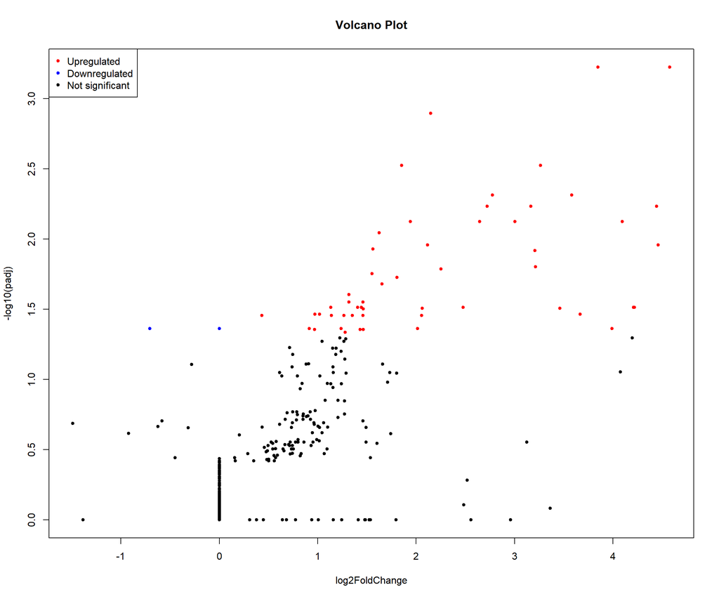

```r
# volcano plot of DESeq results with colors
# create color vector based on significance and direction
colors <- ifelse(resLFC$padj < 0.05 & resLFC$log2FoldChange > 0, "red",  # Upregulated (red)
                 ifelse(resLFC$padj < 0.05 & resLFC$log2FoldChange < 0, "blue",  # Downregulated (blue)
                        "black"))  # Not significant (black)

plot(resLFC$log2FoldChange, -log10(resLFC$padj),
     pch=20,
     col=colors,
     main="Volcano Plot",
     xlab="log2FoldChange",
     ylab="-log10(padj)")
# add legend
legend("topleft", legend = c("Upregulated", "Downregulated", "Not significant"), col = c("red", "blue", "black"), pch = 20)
```

```r
# clear the graph format
dev.off()
```

**VOLCANO PLOT OBTAINED FROM GEO2R ANALYSIS (DEFAULT SETTINGS)**

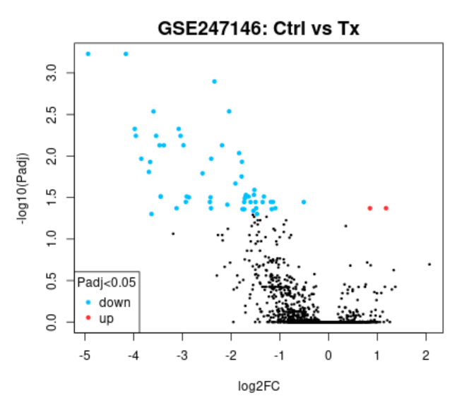

**Discussion:**  
There are significant differences observed from these two plots that have been obtained from two different approaches. The volcano plot obtained from GEO2R (bottom plot) with default analysis settings, shows a narrow range of log2FC values, approximately from -5 to +2, with most of the significant genes clustered in the negative range. In this case, GEO2R predominantly identified downregulated genes as significant (blue dots) and very few upregulated genes (red dots) were identified. The volcano plot obtained from DESeq2 analysis (top plot), shows more positive data points, from -1 to +4, indicating most of the upregulated genes (red dots) as significant. This analysis showed the exact opposite plot to GEO2R, which can be confusing.  
GEO2R analysis utilizes limma, that is generally used for microarray data sets, and the p-value adjustment and fold change thresholds may be more conservative. This could be the reason why it may not be the best method for RNA-seq analysis, which is this data set. DESeq2 analysis is designed for count-based RNA-seq data sets. The log2 fold change shrinkage process analys reduces any inflated fold change estimates, especially for genes with low counts or high variability, and helps make it more reliable and reproducible. The effect size estimates from DESeq2 analysis also provides more realistic estimates for biological interpretation.  
Based on GEO2R analysis, the treatment in this dataset primarily caused down-regulation of gene expression. However, DESeq2 analysis identified more upregulation of genes instead. In this case, I would agree with DESeq2 analysis findings because this package is specifically designed for this data set.

# 2 Normalization Techniques

## 2.1 Importance of Normalization and the Methods

Data normalization is a necessary step to enhance reliability and interpretability when processing gene expression data. There is inherent biological and technical variability in the data which can arise from, for example, experimental conditions, sample handling, or processing times.[1] The main goal is to make gene counts comparable within and between samples.

Limma differential expression analysis operates by getting individual variance estimates from each gene based on its mean expression level, and explicitly models the mean-variance relationship found in count data. It can handle genes with sparse expression better than simple count-based methods. Limma can be used for multiple platforms, like microarray and RNA-seq, and it has the ability to analyze gene expression profiles in terms of co-regulated gene sets and higher-order expression signatures, providing better biological interpretations of gene expression differences.[3] It operates on a matrix of expression values and integrates statistical principles effectively for large-scale expression studies, enabling data import, pre-processing, quality assessment, normalization, and linear modeling.[3] Overall, it has a robust variance modeling, great computational efficiency, and flexible experimental design handling that makes it particularly valuable for complex studies and large-scale analyses.

Variance stabilization normalization (VSN) performs a model fit to the data (usually a linear model) that enables sample normalization.[2] Then it proceeds to perform log transformation to stabilize the asymptotic variance of microarray data across the full range of the data, as well as making it more symmetric.[4] The result is a robust estimate of the replicate mean and standard deviation of the data transformed, where the standard deviation remain constant across the full range of the data.[4] Having stabilized the data variance, it is much easier to further analyze the data as desired.

References:  
[1] Duran R.C., Wei, H. and Wu, J. (2024). Data normalization for addressing the challenges in the analysis of single-cell transcriptomic datasets. BMC genomics, 25(1). doi:https://doi.org/10.1186/s12864-024-10364-5.  
[2] Poudel, R. (2025). RNA-Seq data, normalization, feature selection, and the DESeq package. RBIF112 Week 2 Notes, Brandeis University GPS.  
[3] Ritchie, M. E., Phipson, B., Wu, D., Hu, Y., Law, C. W., Shi, W., & Smyth, G. K. (2015). limma powers differential expression analyses for RNA-sequencing and microarray studies. Nucleic acids research, 43(7), e47. https://doi.org/10.1093/nar/gkv007.  
[4] Durbin, B., Hardin, J., Hawkins, D., & Rocke, D. (2002). A Variance-Stabilizing Transformation for Gene-Expression Microarray Data. Bioinformatics, 18. Retrieved from https://escholarship.org/uc/item/37j5b4z7

```r
# load data set package
library(airway)
# load the data
data(airway)
# view a summary of the data
airway
```

```
## class: RangedSummarizedExperiment
## dim: 63677 8
## metadata(1): ''
## assays(1): counts
## rownames(63677): ENSG00000000003 ENSG00000000005 ... ENSG00000273492
##   ENSG00000273493
## rowData names(10): gene_id gene_name ... seq_coord_system symbol
## colnames(8): SRR1039508 SRR1039509 ... SRR1039520 SRR1039521
## colData names(9): SampleName cell ... Sample BioSample
```

```r
## Create SummarizedExperiment object of array data ##

# create the components for Summarized Experiment object
# 1. create row data (gene annotations)
airway_row_data <- rowData(airway)
# specify which columns are annotations
airway_row_data <- airway_row_data[, c("symbol", "gene_id", "gene_name")]
# the SYMBOL column is used to identify the unique rows
# change row names to SYMBOL
rownames(airway_row_data) <- airway_row_data$symbol


# 2. create count matrix (matrix of expression)
airway_count <- assays(airway)[["counts"]]
# view the matrix by grabbing the first 3 rows and 4 columns
airway_count[1:3, 1:4]
```

```
##                 SRR1039508 SRR1039509 SRR1039512 SRR1039513
## ENSG00000000003        679        448        873        408
## ENSG00000000005          0          0          0          0
## ENSG00000000419        467        515        621        365
```

```r
# change the column names to SampleName
colnames(airway_count) <- colData(airway)$SampleName
# change the row names to SYMBOL, the same as the row data
rownames(airway_count) <- rownames(airway_row_data)


# 3. create column data or the sample metadata
airway_col_data <- colData(airway)
# specify which columns are needed
airway_col_data <- airway_col_data[, c("SampleName", "dex", "cell", "Run")]
# view the first 6 rows and 5 columns of the column data
head(airway_col_data)
```

```
## DataFrame with 6 rows and 4 columns
##            SampleName      dex     cell        Run
##              <factor> <factor> <factor>   <factor>
## SRR1039508 GSM1275862    untrt  N61311  SRR1039508
## SRR1039509 GSM1275863    trt    N61311  SRR1039509
## SRR1039512 GSM1275866    untrt  N052611 SRR1039512
## SRR1039513 GSM1275867    trt    N052611 SRR1039513
## SRR1039516 GSM1275870    untrt  N080611 SRR1039516
## SRR1039517 GSM1275871    trt    N080611 SRR1039517
```

```r
# change the row names to the SampleName
rownames(airway_col_data) <- airway_col_data$SampleName
# add a column called Condition to the data to specify Control and Treatment samples
airway_col_data$Condition <- airway_col_data$dex


# combine components 1-3 above to create the SummarizedExperiment object
airway_SE <- SummarizedExperiment(
  assays = list(counts = airway_count),
  rowData = airway_row_data,
  colData = airway_col_data
)

# show the SummarizedExperiment object
print(airway_SE)
```

```
## class: SummarizedExperiment
## dim: 63677 8
## metadata(0):
## assays(1): counts
## rownames(63677): TSPAN6 TNMD ... AP000230.1 RP11-80H18.4
## rowData names(3): symbol gene_id gene_name
## colnames(8): GSM1275862 GSM1275863 ... GSM1275874 GSM1275875
## colData names(5): SampleName dex cell Run Condition
```

## 2.3 Technique 1: Differential Expression Analysis with Limma package (mean normalization)

```r
## Limma-Voom DE Analysis ##

# load necessary packages
library(limma)
library(edgeR)
set.seed(123)

# save the counts data to a new variable
airway_counts <- airway_count  # same data as the count matrix above
head(airway_counts)
```

```
##          GSM1275862 GSM1275863 GSM1275866 GSM1275867 GSM1275870 GSM1275871
## TSPAN6          679        448        873        408       1138       1047
## TNMD              0          0          0          0          0          0
## DPM1            467        515        621        365        587        799
## SCYL3           260        211        263        164        245        331
## C1orf112         60         55         40         35         78         63
## FGR               0          0          2          0          1          0
##          GSM1275874 GSM1275875
## TSPAN6          770        572
## TNMD              0          0
## DPM1            417        508
## SCYL3           233        229
## C1orf112         76         60
## FGR               0          0
```

```r
# create a DGEList object
airway_dge <- DGEList(airway_counts)  #
head(airway_dge)
```

```
## An object of class "DGEList"
## $counts
##          GSM1275862 GSM1275863 GSM1275866 GSM1275867 GSM1275870 GSM1275871
## TSPAN6          679        448        873        408       1138       1047
## TNMD              0          0          0          0          0          0
## DPM1            467        515        621        365        587        799
## SCYL3           260        211        263        164        245        331
## C1orf112         60         55         40         35         78         63
## FGR               0          0          2          0          1          0
##          GSM1275874 GSM1275875
## TSPAN6          770        572
## TNMD              0          0
## DPM1            417        508
## SCYL3           233        229
## C1orf112         76         60
## FGR               0          0
##
## $samples
##            group lib.size norm.factors
## GSM1275862     1 20637971            1
## GSM1275863     1 18809481            1
## GSM1275866     1 25348649            1
## GSM1275867     1 15163415            1
## GSM1275870     1 24448408            1
## GSM1275871     1 30818215            1
## GSM1275874     1 19126151            1
## GSM1275875     1 21164133            1
```

```r
# calculate normalization factors
airway_normfac <- calcNormFactors(airway_dge)  # the function doesn't actually normalize the data, it just calculates factors for use downstream
airway_normfac                                 # it returns a numeric column storing the calculated normalization factors
```

```
## An object of class "DGEList"
## $counts
##          GSM1275862 GSM1275863 GSM1275866 GSM1275867 GSM1275870 GSM1275871
## TSPAN6          679        448        873        408       1138       1047
## TNMD              0          0          0          0          0          0
## DPM1            467        515        621        365        587        799
## SCYL3           260        211        263        164        245        331
## C1orf112         60         55         40         35         78         63
##          GSM1275874 GSM1275875
## TSPAN6          770        572
## TNMD              0          0
## DPM1            417        508
## SCYL3           233        229
## C1orf112         76         60
## 63672 more rows ...
##
## $samples
##            group lib.size norm.factors
## GSM1275862     1 20637971    1.0553567
## GSM1275863     1 18809481    1.0291947
## GSM1275866     1 25348649    0.9832690
## GSM1275867     1 15163415    0.9490081
## GSM1275870     1 24448408    1.0255871
## GSM1275871     1 30818215    0.9729022
## GSM1275874     1 19126151    1.0308785
## GSM1275875     1 21164133    0.9592055
```

```r
# filter out any low expressed genes
# first specify the (arbitrary) numeric cutoff to filter out genes which max expression below 1 CPM
cutoff <- 1
# convert raw counts to counts-per-million values, applying it across rows and finding the max CPM across samples, then
# checks if the max CPM for each gene is less than 1
drop <- which(apply(cpm(airway_normfac), 1, max) < cutoff)
# subsets the object by removing rows that didn't pass the CPM cutoff, and
# returns a new object with filtered gene counts, normalization factors, and the metadata
airway_dge_filtered <- airway_normfac[-drop,]
# check number of genes after filtering
dim(airway_dge_filtered)
```

```
## [1] 15572     8
```

```r
# specify groups, control and treatment, for the 8 samples in the data set
condition <- c("Control", "Treatment", "Control", "Treatment", "Control", "Treatment", "Control", "Treatment")


# build design matrix used in limma linear modeling, where
# the condition will create one column per factor level and +0 removes the intercept where there are indicator variables for each group.
# the design matrix contains each column is a group (factor), each row is a sample, and values of 0/1 for the grouping
airway_modelmatrix <- model.matrix(~0+condition)
# returns a numeric matrix with dimensions [n samples x n groups]
# two columns each for control and treatment groups, and
# there are 0/1 values within the columns to indicate the grouping
head(airway_modelmatrix)
```

```
##   conditionControl conditionTreatment
## 1                1                  0
## 2                0                  1
## 3                1                  0
## 4                0                  1
## 5                1                  0
## 6                0                  1
```

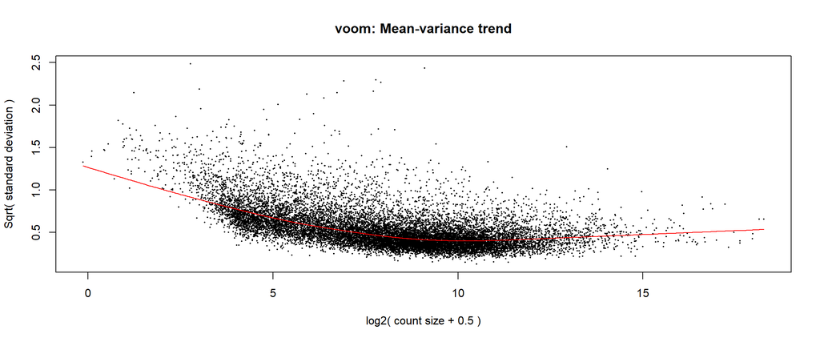

```r
# voom transformation and calculation of variance weights
# this transforms counts into log2 counts-per-million (logCPM) which estimates the mean variance relationship and
# assigns precision weights for each observation.
airway_voom <- voom(airway_dge_filtered, design = airway_modelmatrix, plot = TRUE)
```

```r
# returns an object containing the logCPM expression values (genes x samples), weights, and normalization info
head(airway_voom)
```

```
## An object of class "EList"
## $targets
##            group lib.size norm.factors
## GSM1275862     1 21780421    1.0553567
## GSM1275863     1 19358619    1.0291947
## GSM1275866     1 24924542    0.9832690
## GSM1275867     1 14390204    0.9490081
## GSM1275870     1 25073972    1.0255871
## GSM1275871     1 29983109    0.9729022
## GSM1275874     1 19716738    1.0308785
## GSM1275875     1 20300752    0.9592055
##
## $E
##          GSM1275862 GSM1275863 GSM1275866 GSM1275867 GSM1275870 GSM1275871
## TSPAN6     4.963370   4.534060  5.1311687   4.827177   5.504800   5.126656
## DPM1       4.423863   4.734924  4.6401154   4.666712   4.550326   4.736876
## SCYL3      3.580180   3.449610  3.4021640   3.514929   3.291461   3.466787
## C1orf112   1.473903   1.519512  0.7003549   1.302732   1.646502   1.082607
## CFH        7.221930   7.570390  7.9533122   8.207080   8.066449   8.522740
## FUCA2      6.040366   5.778343  6.1199770   5.936802   5.828121   5.585274
##          GSM1275874 GSM1275875
## TSPAN6     5.288302   4.817671
## DPM1       4.404283   4.646643
## SCYL3      3.565930   3.498889
## C1orf112   1.956039   1.575402
## CFH        8.036412   8.621511
## FUCA2      6.107511   5.772233
##
## $weights
##           [,1]      [,2]      [,3]     [,4]      [,5]      [,6]     [,7]
## [1,] 37.566651 34.101479 38.256222 30.27385 38.278107 37.845367 36.86691
## [2,] 32.830937 33.020311 34.426537 28.91983 34.492427 37.295089 31.52935
## [3,] 22.239102 20.775201 24.228422 16.82602 24.320029 27.276904 20.81404
## [4,]  8.115149  7.116202  8.964239  5.58311  9.003881  9.871609  7.52324
## [5,] 30.237814 29.041835 29.268005 31.19935 29.225726 26.182943 30.97342
## [6,] 38.404268 38.582170 38.021465 37.34883 38.002697 37.998067 38.58223
##           [,8]
## [1,] 34.623448
## [2,] 33.630883
## [3,] 21.441837
## [4,]  7.391163
## [5,] 28.712268
## [6,] 38.637297
##
## $design
##   conditionControl conditionTreatment
## 1                1                  0
## 2                0                  1
## 3                1                  0
## 4                0                  1
## 5                1                  0
## 6                0                  1
## 7                1                  0
## 8                0                  1
## attr(,"assign")
## [1] 1 1
## attr(,"contrasts")
## attr(,"contrasts")$condition
## [1] "contr.treatment"
```

```r
# fit linear model to voom normalized data
# this fits a linear model for each gene across samples and uses the design matrix to model group differences
airway_fit <- lmFit(airway_voom, airway_modelmatrix)
# returns an array object [6 x n conditions] with fitted model parameters, like coefficients, std error, residuals, etc.
# coef() function extracts the matrix of estimated regression coefficients from the fitted model
head(coef(airway_fit))
```

```
##          conditionControl conditionTreatment
## TSPAN6           5.222521           4.834551
## DPM1             4.507818           4.698279
## SCYL3            3.453203           3.480011
## C1orf112         1.421741           1.348957
## CFH              7.817687           8.221615
## FUCA2            6.024365           5.767501
```

```r
dim(airway_fit)
```

```
## [1] 15572     2
```

```r
# test average expression in control minus treatment for each gene
gene_contrast <- makeContrasts(conditionControl - conditionTreatment, levels = colnames(coef(airway_fit)))
# returns a contrast matrix (numeric) with coefficients for the linear combination
# if positive it's higher in control; if negative it's higher in treatment
gene_contrast
```

```
##                     Contrasts
## Levels               conditionControl - conditionTreatment
##   conditionControl                                       1
##   conditionTreatment                                    -1
```

```r
# estimate contrasts for each gene
# applies the contrast to the fitted model and computes coeff., std error, t-stats
est_contrast <- contrasts.fit(airway_fit, gene_contrast)
# returns an array object where the coef now represents the contrast estimates

# empirical Bayes smoothing of standard errors stabilizes variance estimates, and
# adds a moderated t-stats, p-value, adj p-values to the model fit
est_contrast <- eBayes(est_contrast)
# returns an array object with empirical Bayes results
head(est_contrast)
```

```
## An object of class "MArrayLM"
## $coefficients
##           Contrasts
##            conditionControl - conditionTreatment
##   TSPAN6                              0.38797043
##   DPM1                               -0.19046104
##   SCYL3                              -0.02680833
##   C1orf112                            0.07278379
##   CFH                                -0.40392820
##   FUCA2                               0.25686386
##
## $stdev.unscaled
##           Contrasts
##            conditionControl - conditionTreatment
##   TSPAN6                               0.1180318
##   DPM1                                 0.1225945
##   SCYL3                                0.1500055
##   C1orf112                             0.2512601
##   CFH                                  0.1305344
##   FUCA2                                0.1144116
##
## $sigma
## [1] 1.4359473 0.4920462 0.4786303 1.1963726 2.3752101 0.8588167
##
## $df.residual
## [1] 6 6 6 6 6 6
##
## $cov.coefficients
##                                        Contrasts
## Contrasts                               conditionControl - conditionTreatment
##   conditionControl - conditionTreatment                                   0.5
##
## $pivot
## [1] 1 2
##
## $rank
## [1] 2
##
## $Amean
##   TSPAN6     DPM1    SCYL3 C1orf112      CFH    FUCA2
```

[output cut: 66 more lines]

```
## $lods
##           Contrasts
##            conditionControl - conditionTreatment
##   TSPAN6                               -4.311907
##   DPM1                                 -4.570797
##   SCYL3                                -6.703873
##   C1orf112                             -6.205196
##   CFH                                  -5.743371
##   FUCA2                                -4.317337
##
## $F
## [1] 6.46649691 5.56454608 0.07516922 0.06755448 2.33309288 6.54133297
##
## $F.p.value
## [1] 0.03202479 0.04320108 0.79026222 0.80089233 0.16165543 0.03126944
```

```r
# view genes most differentially expressed
# extract the final DE results ranked by contrast & Bayes, sorts by ascending p-value, and
# returns all genes instead of top 10 (default is n=10)
top_table <- topTable(est_contrast, sort.by = "P", n = Inf)
# result is data frame of each gene per row containing statistical results
head(top_table, 20)
```

```
##            ID     logFC  AveExpr         t      P.Value    adj.P.Val        B
## 7281  SPARCL1 -4.568018 4.165462 -18.81733 1.986284e-08 0.0001835068 8.956640
## 6915     STOM -1.434063 8.854588 -16.86607 5.097528e-08 0.0001835068 8.812039
## 10537    PER1 -3.178896 4.418980 -16.80759 5.251809e-08 0.0001835068 8.713615
## 5334     PHC2 -1.374735 6.837469 -16.59532 5.856967e-08 0.0001835068 8.913400
## 4385     MT2A -2.192492 7.022630 -16.58372 5.892204e-08 0.0001835068 8.880246
## 3963    DUSP1 -2.944627 6.643013 -15.75106 9.159760e-08 0.0002377263 8.493845
## 10920    ABAT -1.142285 4.430619 -15.31624 1.163463e-07 0.0002395027 8.248567
## 11783  SLC6A9  2.219311 3.024889  15.19047 1.248275e-07 0.0002395027 7.592842
## 10489  KCTD12  2.536567 6.450283  14.97530 1.409745e-07 0.0002395027 8.115302
## 2015   SAMHD1 -3.774333 8.133814 -14.57822 1.772229e-07 0.0002395027 7.826223
## 11665    MAOA -3.328185 5.949117 -14.55723 1.794089e-07 0.0002395027 7.880020
## 8144     NEXN -2.028644 7.636408 -14.50882 1.845641e-07 0.0002395027 7.845378
## 6565  FAM171B  1.362988 5.773103  14.35578 2.019742e-07 0.0002419340 7.823583
## 8145   DNAJB4 -1.502875 5.903480 -14.15126 2.281494e-07 0.0002537673 7.715537
## 3628  ARHGEF2  1.032629 6.628677  13.76220 2.889850e-07 0.0003000050 7.486025
## 1658    FKBP5 -4.004235 5.779319 -13.61838 3.158635e-07 0.0003074142 7.330188
## 1142    JADE1 -1.190638 6.072405 -13.31131 3.830324e-07 0.0003394621 7.232885
## 10745   RAP2B  1.277741 4.743962  13.27332 3.923913e-07 0.0003394621 7.175404
## 3360    ARMC8 -1.333759 5.403342 -12.95586 4.812824e-07 0.0003944489 7.012120
## 8561   STEAP1 -1.556033 6.279994 -12.81229 5.286349e-07 0.0004115951 6.922993
```

```r
# get the number of most significant genes with alpha < 0.05
length(which(top_table$adj.P.Val < 0.05))
```

```
## [1] 1860
```

## 2.4 Technique 2: Limma DE Analysis using (pre-processed) Variance Stabilization normalized data

Advantages of the VSN technique include stabilization of the variance where it is approximately constant across the whole dynamic range of expression intensities. This is crucial because in many datasets, variance can change with the mean, leading to difficulties in the analysis, especially for weakly expressed genes. In other words, this takes care of the phenomenon where the variance depends on the intensity, where low mean intensities may have a high variance, whereas the large mean intensities the variance is relatively constant.[5] Therefore, this approach allows for the quantification of differential expression independent from the mean intensities. Additionally, this approach enables multivariate analysis and offers model-based, interpretable solution to normalization issues commonly faced in microarray data sets.[6] There are a couple drawbacks. First, the method measures expression differences using a function with two estimated, experiment-specific parameters, which can complicate interpretation.[6] In contrast, the log-ratio can be calculated directly from calibrated data without additional parameters and is easily interpreted as a fold-change. Second, for small intensities near the detection limit, the values derived from the method gets closer to zero, which could affect results and/or biological interpretability.[6]

Reference: [5] Steinhoff, C. (2006). Normalization and quantification of differential expression in gene expression microarrays. Briefings in Bioinformatics, 7(2), pp.166–177. doi:https://doi.org/10.1093/bib/bbl002. [6] Huber, W., Von Heydebreck, A., Sültmann, H., Poustka, A. and Vingron, M., 2002. Variance stabilization applied to microarray data calibration and to the quantification of differential expression. Bioinformatics, 18(suppl_1), pp.S96-S104.

```r
# load relevant package for normalization technique
library(NormalyzerDE)

# filter out values with low counts
CountFilter <- function(airway_count, cutoff = 5){  # function to filter out expression values <5 from the airway_count matrix
    submat <- as.matrix(airway_count) >= cutoff     # convert the input into a matrix, and create a True/False matrix where True means the count >= cutoff
    counts <- rowSums(submat)                       # for each row count how many samples have counts >= cutoff, produces a vector
    counts <- counts[counts >= (ncol(submat)/2)]    # keep only genes expressed in at least half the samples
    return(airway_count[rownames(airway_count) %in% names(counts),])  # subset the count matrix, keep rows that meet criteria above, return filtered matrix
}

# save the filtered matrix into a new variable
airway_count_filtered <- CountFilter(airway_count = airway_count)
dim(airway_count_filtered)  # check the dimensions of the new matrix
```

```
## [1] 21208     8
```

```r
## Perform Variance Stabilization Normalization ##
# normalize the filtered matrix raw expression data using VSN technique
# save into a new variable
airway_vsn_norm <- performVSNNormalization(airway_count_filtered)
head(airway_vsn_norm)  # view the normalization data
```

```
##          GSM1275862 GSM1275863 GSM1275866 GSM1275867 GSM1275870 GSM1275871
## TSPAN6     9.407268   8.807355   9.769838   8.672425  10.152285  10.032046
## DPM1       8.867279   9.008429   9.278449   8.511753   9.197217   9.642052
## SCYL3      8.022368   7.721099   8.038919   7.357552   7.936638   8.370687
## C1orf112   5.906891   5.781360   5.321928   5.129283   6.285402   5.977280
## CFH       11.666668  11.845098  12.592691  12.053926  12.714460  13.428753
## FUCA2     10.484823  10.052568  10.759056   9.782998  10.475733  10.490851
##          GSM1275874 GSM1275875
## TSPAN6     9.588715   9.159871
## DPM1       8.703904   8.988685
## SCYL3      7.864186   7.839204
## C1orf112   6.247928   5.906891
## CFH       12.337622  12.964882
## FUCA2     10.408330  10.115044
```

```r
## DE Analysis with Limma package ##

# fit vsn normalized data to linear model
# this fits a linear model for each gene across samples and uses the design matrix to model group differences
airway_fit2 <- lmFit(airway_vsn_norm, airway_modelmatrix)
# returns an array object [6 x n conditions] with fitted model parameters, like coefficients, std error, residuals, etc.
# coef() function extracts the matrix of estimated regression coefficients from the fitted model
head(coef(airway_fit2))
```

```
##          conditionControl conditionTreatment
## TSPAN6           9.729526           9.167924
## DPM1             9.011712           9.037729
## SCYL3            7.965528           7.822136
## C1orf112         5.940537           5.698703
## CFH             12.327860          12.573165
## FUCA2           10.531986          10.110365
```

```r
# check the data dimensions (row x columns)
dim(airway_fit2)
```

```
## [1] 21208     2
```

```r
# test average expression in control minus treatment for each gene
gene_contrast2 <- makeContrasts(conditionControl - conditionTreatment, levels = colnames(coef(airway_fit2)))
# returns a contrast matrix (numeric) with coefficients for the linear combination
# if positive it's higher in control; if negative it's higher in treatment
gene_contrast2
```

```
##                     Contrasts
## Levels               conditionControl - conditionTreatment
##   conditionControl                                       1
##   conditionTreatment                                    -1
```

```r
# estimate contrasts for each gene
# applies the contrast to the fitted model and computes coeff., std error, t-stats
est_contrast2 <- contrasts.fit(airway_fit2, gene_contrast2)
# returns an array object where the coef now represents the contrast estimates
head(est_contrast2)
```

```
## An object of class "MArrayLM"
## $coefficients
##           Contrasts
##            conditionControl - conditionTreatment
##   TSPAN6                               0.5616019
##   DPM1                                -0.0260173
##   SCYL3                                0.1433921
##   C1orf112                             0.2418338
##   CFH                                 -0.2453046
##   FUCA2                                0.4216203
##
## $rank
## [1] 2
##
## $assign
## [1] 1 1
##
## $qr
## $qr
##   conditionControl conditionTreatment
## 1             -2.0                0.0
## 2              0.0               -2.0
## 3              0.5                0.0
## 4              0.0                0.5
## 5              0.5                0.0
## 6              0.0                0.5
## 7              0.5                0.0
## 8              0.0                0.5
## attr(,"assign")
## [1] 1 1
## attr(,"contrasts")
## attr(,"contrasts")$condition
## [1] "contr.treatment"
##
##
## $qraux
## [1] 1.5 1.5
##
## $pivot
## [1] 1 2
```

[output cut: 47 more lines]

```
## 6                0                  1
## 7                1                  0
## 8                0                  1
## attr(,"assign")
## [1] 1 1
## attr(,"contrasts")
## attr(,"contrasts")$condition
## [1] "contr.treatment"
##
##
## $contrasts
##                     Contrasts
## Levels               conditionControl - conditionTreatment
##   conditionControl                                       1
##   conditionTreatment                                    -1
```

```r
# empirical Bayes smoothing of standard errors stabilizes variance estimates, and
# adds a moderated t-stats, p-value, adj p-values to the model fit
est_contrast2 <- eBayes(est_contrast2)
# returns an array object with empirical Bayes results


# view genes most differentially expressed
# extract the final DE results ranked by contrast & Bayes, sorts by ascending p-value, and
# returns all genes instead of top 10 (default is n=10)
top_table2 <- topTable(est_contrast2, sort.by = "P", n = Inf)
# result is data frame of each gene per row containing statistical results
head(top_table2, 20)
```

```
##                ID       logFC    AveExpr          t      P.Value    adj.P.Val
## 11166     ALOX15B -152.079242 -69.157438 -500.09928 9.515007e-17 1.329613e-12
## 5350       GUCY2D -148.446971 -70.973574 -480.16665 1.253879e-16 1.329613e-12
## 14024       Y_RNA  145.664733 -72.332366  308.38744 2.528704e-15 1.787625e-11
## 15969 RP5-965F6.2   -3.249912   1.624956  -18.16539 5.257617e-07 2.505492e-03
## 7623      SPARCL1   -4.407465   8.586530  -17.85060 5.906950e-07 2.505492e-03
## 2109       SAMHD1   -3.585474  12.559261  -16.38360 1.044649e-06 3.391462e-03
## 2106        TLDC2   -3.908778   4.181112  -15.91969 1.263879e-06 3.391462e-03
## 5542       TRIM45    2.140320   6.779336   15.65277 1.413703e-06 3.391462e-03
## 6761        VASH2    4.054220   3.173350   15.61053 1.439229e-06 3.391462e-03
## 7900        CLIC2    1.434984   8.514773   14.23631 2.645576e-06 5.529198e-03
## 265        CLDN11    1.955105  11.462732   14.06304 2.867841e-06 5.529198e-03
## 12115        MT1X   -2.991395   4.458635  -13.00391 4.796765e-06 7.834878e-03
## 2594          DBP    1.827000   6.180043   12.95382 4.919605e-06 7.834878e-03
## 10384       HSPA6    2.825649   3.182028   12.85523 5.172024e-06 7.834878e-03
```

[output cut: 27 more lines]

```r
# get the number of most significant genes with alpha < 0.05
length(which(top_table2$adj.P.Val < 0.05))
```

```
## [1] 113
```

## 2.5 Comparison of the Fold Change values between the Limma-Voom and Variance Normalization analyses

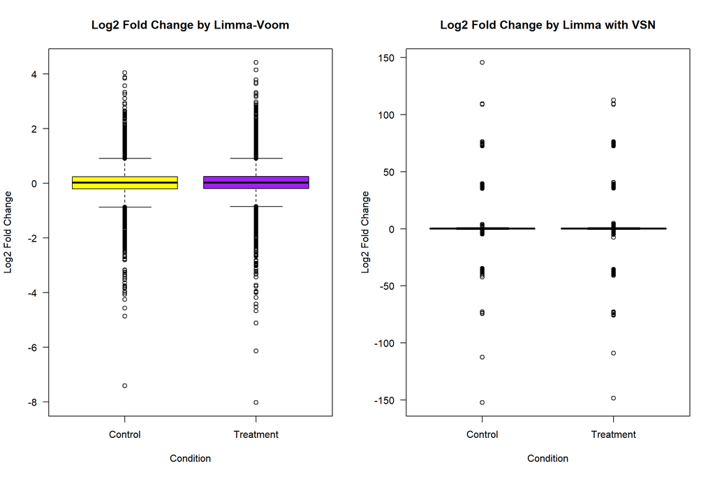

```r
# create grid view of the plots to be 1 row and 2 columns for side-by-side visualization
oldpar <- par(mfrow=c(1,2))

## plot log2 fold change from est_contrast results ##
# create variable to grab the log2 FC values divided into each group, control and treatment
plot_data <- data.frame(
    log2_FC = top_table$logFC,
    Condition = rep(c("Control", "Treatment"), length.out = length(top_table$logFC))
)
boxplot(log2_FC ~ Condition,
        data = plot_data,
        las = 1,
        col = c("yellow", "purple"),
        main = "Log2 Fold Change by Limma-Voom",
        ylab = "Log2 Fold Change")


## plot log2 fold change from Variance Stabilization normalization ##
# create variable to grab the log2 FC values divided into each group, control and treatment
plot_data2 <- data.frame(
    log2_FC = top_table2$logFC,
    Condition = rep(c("Control", "Treatment"), length.out = length(top_table2$logFC))
)

boxplot(log2_FC ~ Condition,
        data = plot_data2,
        las = 1,
        col = c("lightblue", "lightcoral"),
        main = "Log2 Fold Change by Limma with VSN",
        ylab = "Log2 Fold Change")
```

```r
# clear graph formatting
#dev.off()
```